# FPP - Ch. 3 Exercises

##### The Forecaster’s Toolbox

##### Dan Hong | dnaeye@gmail.com

The following are my answers to the exercises in the excellent book [Forecasting: Principles & Practice](https://otexts.org/fpp2/) by Rob J Hyndman and George Athanasopoulos.

#### 1. Find an appropriate Box-Cox transformation to stabilize the variance.

```r
library(fpp2)
BoxCox.lambda(usnetelec)
```

```
[1] 0.5167714
```

```r
BoxCox.lambda(usgdp)
```

```
[1] 0.366352
```

```r
BoxCox.lambda(mcopper)
```

```
[1] 0.1919047
```

```r
BoxCox.lambda(enplanements)
```

```
[1] -0.2269461
```

#### 2. Why is a Box-Cox transformation unhelpful for the cangas data?

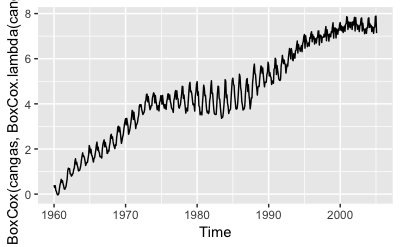

```r
autoplot(BoxCox(cangas, BoxCox.lambda(cangas)))
```

It could not minimize the seasonal variations very much.

#### 3. What Box-Cox transformation would you select for your retail data?

```r
retaildata <- readxl::read_excel("retail.xlsx", skip=1)
retail <- ts(retaildata[,"A3349335T"], frequency=12, start=c(1982,4))
BoxCox.lambda(retail)
```

```
[1] 0.193853
```

Using `BoxCox.lambda` to automatically find the best lambda, it computed 0.193853, so a transformation is recommeded for this series.

#### 4. For each of the following series (dole, usdeaths, bricksq), make a graph of the data. If transforming seems appropriate, do so and describe the effect.

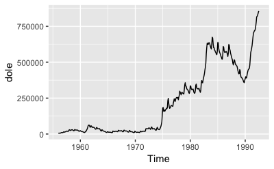

```r
autoplot(dole)
```

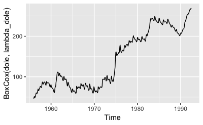

```r
lambda_dole <- BoxCox.lambda(dole)
autoplot(BoxCox(dole, lambda_dole))
```

lambda = 0.3290922

Transforming the series made the seasonal variations early in the series, from 1956 to 1975, more apparent and reduced the scale of the variance later in the series, especially around 1983.

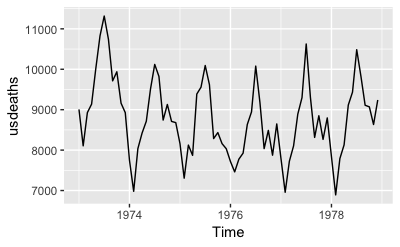

```r
autoplot(usdeaths)
```

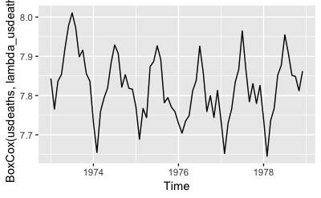

```r
lambda_usdeaths <- BoxCox.lambda(usdeaths)
autoplot(BoxCox(usdeaths, lambda_usdeaths))
```

lambda = -0.0336377

Although the automatic `BoxCox.lambda` function returned a value other than 1, it did not change the shape of the time series.

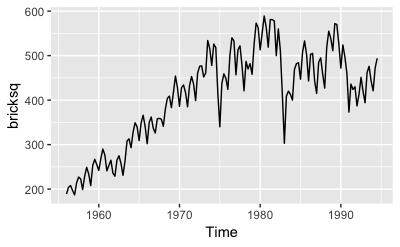

```r
autoplot(bricksq)
```

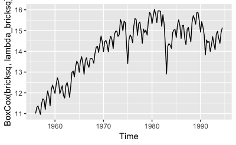

```r
lambda_bricksq <- BoxCox.lambda(bricksq)
autoplot(BoxCox(bricksq, lambda_bricksq))
```

lambda = 0.2548929

In this case, the Box-Cox transformation helped somewhat to normalize the seasonal variance.

#### 5. Calculate the residuals from a seasonal naive forecast applied to the quarterly Australian beer production data from 1992.

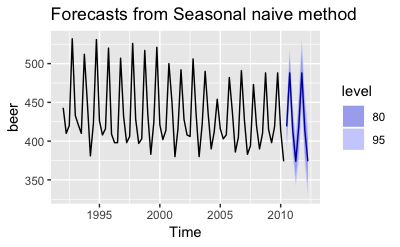

```r
beer <- window(ausbeer, start=1992)
fc <- snaive(beer)
autoplot(fc)
```

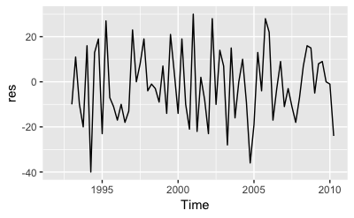

```r
res <- residuals(fc)
autoplot(res)
```

Test if the residuals are white noise and normally distributed.

```
    Ljung-Box test

data:  Residuals from Seasonal naive method
Q* = 32.269, df = 8, p-value = 8.336e-05

Model df: 0.   Total lags used: 8
```

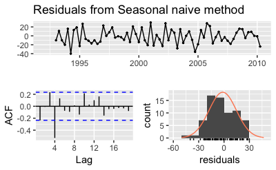

```r
checkresiduals(fc)
```

#### 6. Repeat Exer. 5 with WWWusage and bricksq datasets.

```r
frequency(WWWusage)
```

```
[1] 1
```

There is no observed frequency in `WWWusage`, so the naive method will be used.

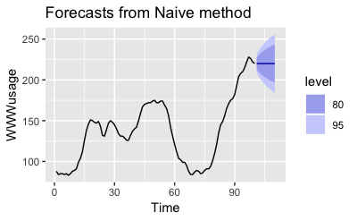

```r
fc <- naive(WWWusage)
autoplot(fc)
```

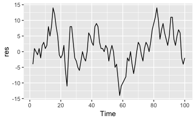

```r
res <- residuals(fc)
autoplot(res)
```

Test residuals.

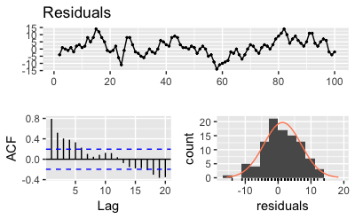

```r
checkresiduals(res)
```

This can be supported by running a Ljung-Box test with a lag, or h, of 10, as suggested in [3.3 Residual diagnostics](https://otexts.org/fpp2/residuals.html) for non-seasonal data.

```r
Box.test(res, lag=10, fitdf=0, type="Lj")
```

```
    Box-Ljung test

data:  res
X-squared = 145.58, df = 10, p-value <
2.2e-16
```

The low p-value (less than 0.05) indicates there is a trend in the data.

```r
frequency(bricksq)
```

```
[1] 4
```

Quarterly frequency is observed in `bricksq`, so the snaive method will be used.

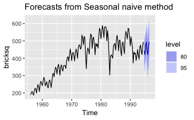

```r
fc <- snaive(bricksq)
autoplot(fc)
```

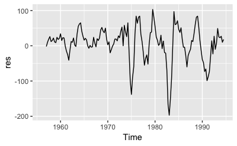

```r
res <- residuals(fc)
autoplot(res)
```

Test residuals.

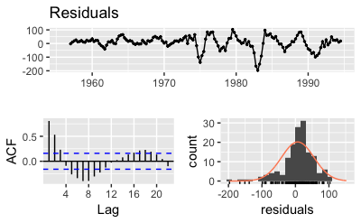

```r
checkresiduals(res)
```

#### 7. Are the following statements true or false? Explain your answer.

**a.** *Good forecast methods should have normally distributed residuals.*  
False. It’s useful for calculating prediction intervals, but not necessary.

**b.** *A model with small residuals will give good forecasts.*  
False. The size of the residuals is not a reliable indication of how large true forecast errors are likely to be. The accuracy of forecasts can only be determined by considering how well a model performs on new data that were not used when fitting the model.

**c.** *The best measure of forecast accuracy is MAPE.*  
False. It is probably the most common one, but not necessarily best. Actually, a better method might be measuring RMSE using time series cross-validation.

**d.** *If your model doesn’t forecast well, you should make it more complicated.*  
False. Adding more variables may lead to a model that fits the historical data perfectly, but it will not produce good forecasts into the future.

**e.** *Always choose the model with the best forecast accuracy as measured on the test set.*  
True.

#### 8. For your retail time series (from Exercise 3 in [Section 2.10](https://otexts.org/fpp2/graphics-exercises.html#graphics-exercises)), do the following:

**8a.** Split retail time series into training and test sets.

```r
retaildata <- readxl::read_excel("retail.xlsx", skip=1)
myts <- ts(retaildata[,"A3349335T"], frequency=12, start=c(1982,4))
myts.train <- window(myts, end=c(2010,12))
myts.test <- window(myts, start=2011)
```

**8b.** Check that your data have been split appropriately by producing the following plot.

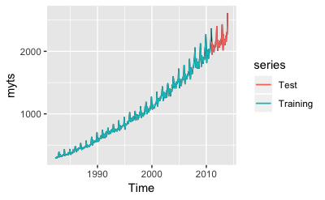

```r
autoplot(myts) +
  autolayer(myts.train, series="Training") +
  autolayer(myts.test, series="Test")
```

**8c.** Calculate forecasts using `snaive` applied to `myts.train`.

```r
fc <- snaive(myts.train)
```

**8d.** Compare the accuracy of your forecasts against the actual values stored in `myts.test`.

```r
accuracy(fc, myts.test)
```

```
                   ME      RMSE       MAE      MPE
Training set 61.56787  72.20702  61.68438 6.388722
Test set     97.44583 109.62545 100.02917 4.629852
                 MAPE     MASE      ACF1 Theil's U
Training set 6.404105 1.000000 0.6018274        NA
Test set     4.751209 1.621629 0.2686595 0.9036205
```

**8e.** Check the residuals.

```
    Ljung-Box test

data:  Residuals from Seasonal naive method
Q* = 812.76, df = 24, p-value < 2.2e-16

Model df: 0.   Total lags used: 24
```

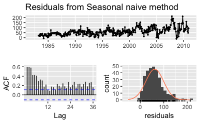

```r
checkresiduals(fc)
```

The low p-value from the Ljung-Box test indicates that there is still trend in the series. This is supported by the residuals plot, which exhibits and upward trend with increasing variance. Also, the ACF plot shows decaying autocorrelation through about lag 12 and then a plateau of positive lags after that. The histogram of residuals tails to the right.

**8f.** How sensitive are the accuracy measures to the training/test split?

*Not sure what is meant by this question.*

#### 9. visnights contains quarterly visitor nights (in millions) from 1998 to 2016 for twenty regions of Australia.

**9a.** Use `window()` to create three training sets for `visnights[,"QLDMetro"]`, omitting the last 1, 2 and 3 years; call these train1, train2, and train3, respectively.

```r
train1 <- window(visnights[, "QLDMetro"], end=c(2015, 4))
train2 <- window(visnights[, "QLDMetro"], end=c(2014, 4))
train3 <- window(visnights[, "QLDMetro"], end=c(2013, 4))
```

**9b.** Compute one year of forecasts for each training set using the `snaive()` method.

```r
fc1 <- snaive(train1, h=4)
fc2 <- snaive(train2, h=4)
fc3 <- snaive(train3, h=4)
```

**9c.** Use `accuracy()` to compare the MAPE over the three test sets. Comment on these.

```r
test1 <- window(visnights[, "QLDMetro"], start=c(2016,1))
test2 <- window(visnights[, "QLDMetro"], start=c(2015,1))
test3 <- window(visnights[, "QLDMetro"], start=c(2014,1))
```

```r
fc1_acc <- as.data.frame(accuracy(fc1, test1))
fc1_acc
```

```
                     ME      RMSE       MAE
Training set 0.02006107 1.0462821 0.8475553
Test set     0.56983879 0.9358727 0.7094002
                    MPE     MAPE      MASE
Training set -0.2237701 7.976760 1.0000000
Test set      4.6191866 6.159821 0.8369957
                   ACF1 Theil's U
Training set 0.06014484        NA
Test set     0.09003153 0.4842061
```

```r
fc2_acc <- as.data.frame(accuracy(fc2, test2))
fc2_acc
```

```
                     ME      RMSE       MAE
Training set 0.01618760 1.0735582 0.8809432
Test set     0.08203656 0.4117902 0.3133488
                    MPE     MAPE      MASE
Training set -0.2744747 8.284216 1.0000000
Test set      0.5875037 3.057463 0.3556969
                    ACF1 Theil's U
Training set  0.06610879        NA
Test set     -0.59903247 0.3336559
```

```r
fc3_acc <- as.data.frame(accuracy(fc3, test3))
fc3_acc
```

```
                       ME     RMSE       MAE
Training set -0.007455407 1.074544 0.8821694
Test set      0.370832661 1.058658 0.8625501
                    MPE     MAPE      MASE
Training set -0.5625865 8.271365 1.0000000
Test set      4.0472032 8.476977 0.9777602
                    ACF1 Theil's U
Training set  0.07317746        NA
Test set     -0.36890062  1.177346
```

Overall, the model with the lowest test MAPE, 3.0574632, was the 2nd model, whose training set omitted the last 2 years of the original dataset. The next best was the 1st model with a MAPE of 6.1598205, and the worst was the 3rd model, whose test MAPE of 8.4769771 wasn’t much different than its performance on the training set.

#### 10. Use the Dow Jones index (data set dowjones) to do the following:

**10a.** Produce a time plot of the `dowjones` series.

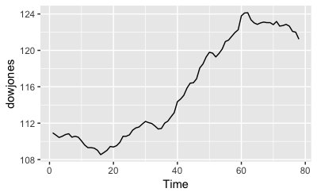

```r
autoplot(dowjones)
```

**10b.** Produce forecasts using the drift method and plot them.  
**10c.** Show that the forecasts are identical to extending the line drawn between the first and last observations.

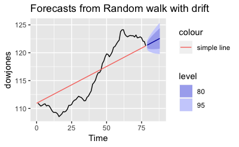

```r
dj_drift <- rwf(dowjones, drift = TRUE)
autoplot(dj_drift) + geom_segment(aes(x=0, y=dowjones[1], xend=78, yend=tail(dowjones,1)[1], col="simple line"))
```

**10d.** Try using some of the other benchmark functions to forecast the same data set. Which do you think is best? Why?

```r
dj_train <- window(dowjones, end=72)
dj_test <- window(dowjones, start=73)
```

```r
dj_drift <- rwf(dj_train, drift = TRUE)
dj_drift_acc <- as.data.frame(accuracy(dj_drift, dj_test))
```

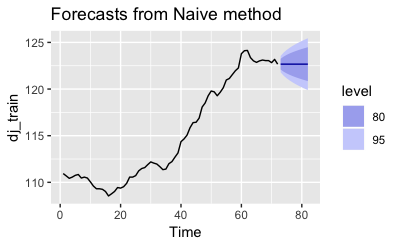

```r
dj_naive <- naive(dj_train)
autoplot(dj_naive)
```

```r
dj_naive_acc <- as.data.frame(accuracy(dj_naive, dj_test))
```

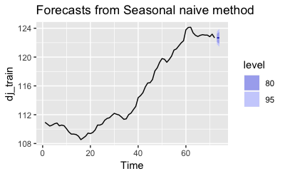

```r
dj_snaive <- snaive(dj_train)
autoplot(dj_snaive)
```

```r
dj_snaive_acc <- as.data.frame(accuracy(dj_snaive, dj_test))
```

The MAPE measures of the various forecast models are as follows:

- Drift: 0.8086951
- Naive: 0.4026
- Snaive: 0.1017677

For the 6-day forecast period (i.e., Day 73-78), the model with the best accuracy was the seasonal naive model.

#### 11. Consider the daily closing IBM stock prices (data set ibmclose).

**11a.** Produce some plots of the data in order to become familiar with it.

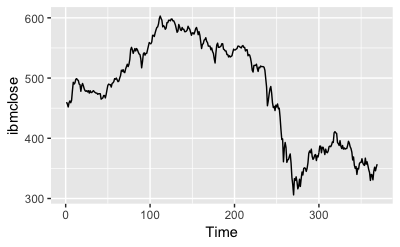

```r
autoplot(ibmclose)
```

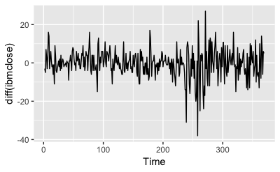

```r
autoplot(diff(ibmclose))
```

**11b.** Split the data into a training set of 300 observations and a test set of 69 observations.

```r
ibm_train <- window(ibmclose, end=300)
ibm_test <- window(ibmclose, start=301, end=370)
```

```
'end' value not changed
```

**11c.** Try using various benchmark methods to forecast the training set and compare the results on the test set. Which method did best?

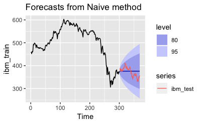

```r
ibm_naive <- naive(ibm_train, h=69)
autoplot(ibm_naive) + autolayer(ibm_test)
```

```r
ibm_naive_acc <- as.data.frame(accuracy(ibm_naive, ibm_test))
```

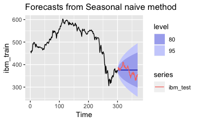

```r
ibm_snaive <- snaive(ibm_train, h=69)
autoplot(ibm_snaive) + autolayer(ibm_test)
```

```r
ibm_snaive_acc <- as.data.frame(accuracy(ibm_snaive, ibm_test))
```

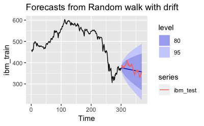

```r
ibm_drift <- rwf(ibm_train, drift = TRUE, h=69)
autoplot(ibm_drift) + autolayer(ibm_test)
```

```r
ibm_drift_acc <- as.data.frame(accuracy(ibm_drift, ibm_test))
```

The MAPE of the various benchmark models are:

- naive: 4.6681858
- snaive: 4.6681858
- drift: 3.7078875

So, the model with the best MAPE was the drift one.

**11d.** Check the residuals of your preferred method. Do they resemble white noise?

```
    Ljung-Box test

data:  Residuals from Random walk with drift
Q* = 22.555, df = 9, p-value = 0.007278

Model df: 1.   Total lags used: 10
```

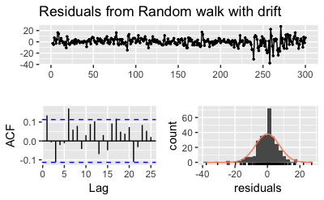

```r
checkresiduals(ibm_drift)
```

The residuals resemble white noise, but the p-value from the Ljung-Box test was low, indicating that it is not white noise and that there is some autocorrelation through lag 10; the residuals plot had points oscillating around a mean of 0; the ACFs for most lags (except lag 6) were within the interval of significance, and the residual distribution plot was mostly normal.

#### 12. Consider the sales of new one-family houses in the USA, Jan 1973 – Nov 1995 (data set hsales).

**12a.** Produce some plots of the data in order to become familiar with it.

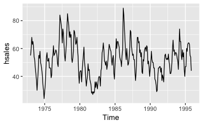

```r
autoplot(hsales)
```

**12b.** Split the hsales data set into a training set and a test set, where the test set is the last two years of data.

```r
hsales_train <- window(hsales, end=c(1993,12))
hsales_test <- window(hsales, start=c(1994,1))
```

**11c.** Try using various benchmark methods to forecast the training set and compare the results on the test set. Which method did best?

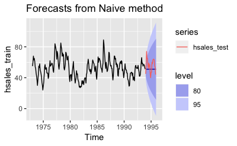

```r
hsales_naive <- naive(hsales_train, h=24)
autoplot(hsales_naive) + autolayer(hsales_test)
```

```r
hsales_naive_acc <- as.data.frame(accuracy(hsales_naive, hsales_test))
```

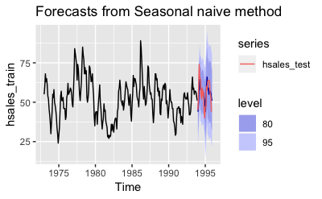

```r
hsales_snaive <- snaive(hsales_train, h=24)
autoplot(hsales_snaive) + autolayer(hsales_test)
```

```r
hsales_snaive_acc <- as.data.frame(accuracy(hsales_snaive, hsales_test))
```

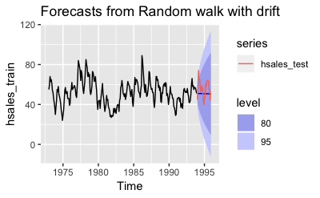

```r
hsales_drift <- rwf(hsales_train, drift = TRUE, h=24)
autoplot(hsales_drift) + autolayer(hsales_test)
```

```r
hsales_drift_acc <- as.data.frame(accuracy(hsales_drift, hsales_test))
```

The MAPE of the various benchmark models are:

- naive: 14.3816734
- snaive: 9.1282798
- drift: 14.5030343

So, the model with the best MAPE was the seasonal naive one.

**12d.** Check the residuals of your preferred method. Do they resemble white noise?

```
    Ljung-Box test

data:  Residuals from Seasonal naive method
Q* = 684.66, df = 24, p-value < 2.2e-16

Model df: 0.   Total lags used: 24
```

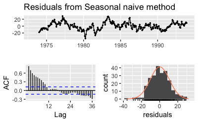

```r
checkresiduals(hsales_snaive)
```

The low p-value of the Ljung-Box test indicated that the residuals were not white noise, and the ACF chart showed significant decaying autocorrelation through lag 11. However, the residuals distribution chart showed a pretty normal distribution with a slight tail to the right.